# Calibrating the nNIL caller against a simulation

The non-informative rate calibrated on a count-from-parents simulation reproduces calibration against the scarce SNP-chip truth

Author

Fausto Rodríguez-Zapata

Published

July 22, 2026

## Thesis

Holland’s nested-NIL (nNIL) introgression caller has one parameter that matters, the **non-informative rate `nir`**, the probability that a donor’s SNP allele is identical in state to B73 so the marker carries no ancestry signal. Zhong et al. (2025) set `nir` by grid search against a **scarce, expensive truth**: 24 of the 888 nNILs re-genotyped on a SNP chip. Here we show that calibrating `nir` against a **simulation**, where the truth is known for free at every marker, lands at the same operating point and produces the same calls on the real data. Simulation can therefore stand in for the scarce chip truth.

The simulation is built from the **real donor genotypes** (not a scalar knob), so a donor’s non-informativeness emerges mechanically and per-donor; this is the fidelity that makes the substitution credible.

## Methods

*(Paper-ready. Cross-references to files are to the Zhong et al. 2025 supplement and to this repository’s tracked scripts.)*

**Count-from-parents simulation.** We simulated the genotyped nNIL population from the genotypes of its actual donors. The 16 NAM founders that produced the 888 GBS-genotyped nNILs were taken from the SNP-chip data of Zhong et al. (2025, File S2) and placed on the GBS marker frame, the 11,310 markers shared between the 20,221 QC-passing chip SNPs and the 64,024-marker GBS set, lifted AGPv3→v4→v5. For each donor we simulated a **BC5S4** family (five backcrosses to the recurrent parent B73, then four generations of selfing, the generation Zhong et al. report for the sequenced material) with `simcross` (Stahl interference m = 10), yielding the latent ancestry mosaic (0/1/2 donor dose) at every marker. The **observed** allelic dose was the ancestry dose multiplied by the founder’s allele at that marker, so a marker is non-informative wherever the donor carries the B73/REF allele. Donor non-informativeness (`nir`) thus emerges **per-donor and spatially** from the real founder genotypes rather than from a scalar parameter; the realized per-donor non-informative rate (`f0` ≈ 0.55) matches the value measured directly from the founder genotypes (0.535). Because Zhong et al. report no per-site read depth and the raw reads are not deposited, we inferred an effective coverage from the observed GBS missing-data rate (`mr` = 0.093), giving λ ≈ 2.7 reads per site (Poisson, with a 1% structural-dropout floor); allele read counts were drawn under this regime with a 1% per-read error. We simulated 40 lines per donor (640 nNILs total).

**Genotype calling.** Simulated read counts were converted to hard genotypes by maximum likelihood (a flat prior; a single ALT read yields a homozygous-ALT call), matching the likelihood-based calling of the TASSEL-GBS pipeline used by Zhong et al.

**Ancestry caller.** Introgressions were called with `nnil` (nilHMM), a reimplementation of Holland’s nested-NIL hidden Markov model: a categorical genotype-confusion emission parameterised by the non-informative rate `nir` (plus genotyping-error rates) and a geometric duration. Each line is decoded independently under a single, donor-agnostic `nir`, as in Zhong et al.; the adjacent-marker recombination fraction was fixed at the genetic-map value ($r = 2L/100n$).

**Calibration.** `nir` was chosen to minimise the **total marker mismatch** between the caller’s states and a reference, the criterion of Zhong et al. (File S16), swept over `nir` ∈ [0.01, 0.95]. Two references define two calibrations: *simulation* (mismatch against the simulated latent ancestry, over all 640 nNILs) and *chip* (mismatch against the SNP-chip introgression calls, over the 24 both-platform nNILs, reproducing Zhong et al.). For interpretation we also measured each donor’s non-informative rate `f0` directly, as the fraction of markers at which the donor genotype equals the B73/REF allele: from the simulated data (realized) and from the real founder genotypes.

**Evaluation.** We compared donor introgression-size distributions (empirical CDFs) of the calibrated caller against the truth on each dataset, and used a QQ plot to compare the per-line introgression sizes obtained on the **same real 24-line GBS** under the simulation-chosen versus chip-chosen `nir`.

**A note on scope.** Count-emission callers such as RTIGER are excluded from this comparison: the released nNIL GBS provides genotype calls but no read counts, and manufacturing counts from the calls to feed a count caller would be circular. RTIGER can be validated on the simulation (where counts exist) but has no real-data leg here.

**Data and code (this repository).** Founder genotypes on the v5 GBS frame: `scripts/nnil_foil/10_founder_genotypes.py`. Effective-coverage / missing-data regime fit: `scripts/nnil_foil/11_fit_gbs_regime.R`. Count-from-parents simulator: `scripts/simulate_nested_nils.R`. Calibration, evaluation, and this figure (with a cached compute step): `scripts/fig_nnil_sim_calibration.R`. Decomposition of the chip-calibration mismatch floor by GBS genotype: `scripts/nnil_chip_floor_decomposition.R`. Real GBS calls: `data/nnil_equiv/geno_recoded.csv`; chip truth: `data/nnil_foil/chip_truth_projected.csv`.

## Figure

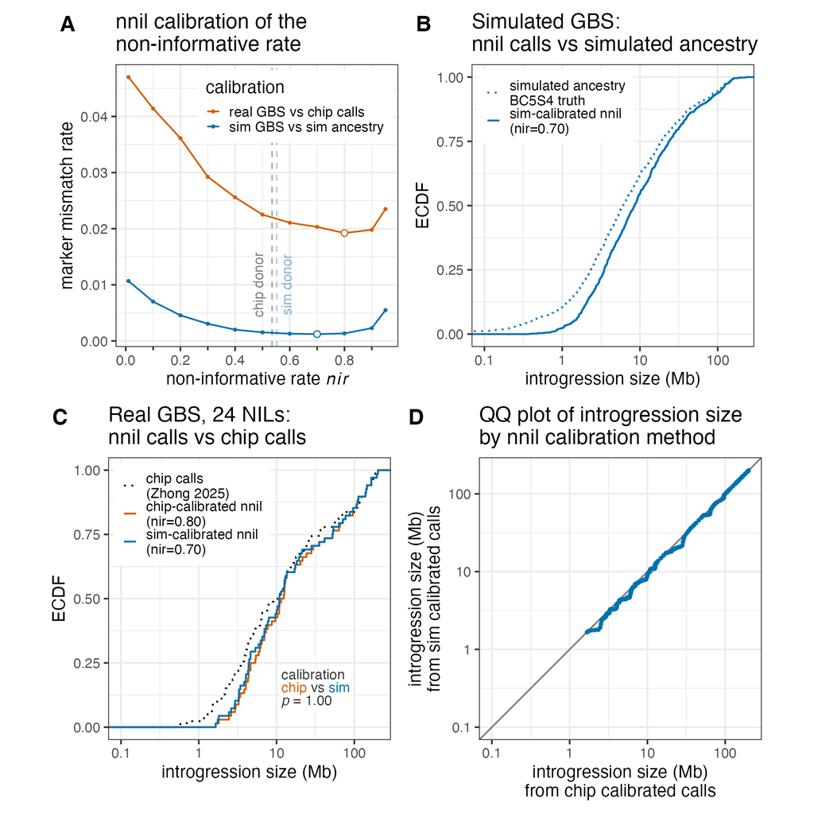

Figure 1: **Ancestry HMM parameter calibrations from `simcross` simulation or chip data are equivalent in the nNIL population.** **(A)** Marker-mismatch calibration curves: total marker mismatch of the `nnil` caller versus `nir`, scored against the simulated ancestry (blue; 640 BC5S4 nNILs from 16 real NAM founders) and against the SNP-chip introgression calls on the 24 both-platform nNILs (orange); open circles mark the chosen operating points, coloured as the resulting caller in panels C and D: blue sim-calibrated at `nir`* = 0.70 and orange chip-calibrated at `nir`* = 0.80, both on the shallow high-`nir` plateau near Zhong et al.’s 0.90. Dashed verticals mark the donors’ measured non-informative rate `f0` (blue, realized in the simulation; black, from the chip founder genotypes), ≈ 0.54, well below the mismatch-optimal `nir`, because the >90% REF background makes marker mismatch a weak criterion that tolerates over-smoothing. **(B)** Donor introgression-size ECDF on the simulated GBS: sim-calibrated `nnil` calls versus the simulated ancestry truth (dotted). **(C)** On the 24 real nNILs, introgression-size ECDFs of the chip- and sim-calibrated `nnil` calls versus the chip calls (Zhong et al. 2025, dotted). Significance: p-value from a two-sample Kolmogorov-Smirnov test. **(D)** QQ plot of per-line introgression sizes from the sim-calibrated versus chip-calibrated `nnil`, both applied to the same real GBS; points on the solid grey 1:1 line indicate the two calibrations yield equivalent calls. RTIGER is omitted because it requires read counts, which the released GBS lacks.

## Caveats / to do

- The `nir` grid is coarse (step 0.1); the plateau (0.5 to 0.9) is real but the exact argmin (0.70 vs 0.80) is within noise. A finer sweep would state the plateau precisely.
- Marker mismatch is Zhong et al.’s criterion and is used here so the sim↔︎chip comparison is on their terms; a donor-recovery metric (e.g. Dice) would sharpen the optimum but is a separate analysis.